# Visualizing Bay Wheels Data (02-2020)

## Introduction

Bay Wheels is a regional public bicycle sharing system in California's San Francisco Bay Area. It is operated by Motivate in a partnership with the Metropolitan Transportation Commission and the Bay Area Air Quality Management District. Bay Wheels is the first regional and large-scale bicycle sharing system deployed in California and on the West Coast of the United States. It was established as Bay Area Bike Share in August 2013. As of January 2018, the Bay Wheels system had over 2,600 bicycles in 262 stations across San Francisco, East Bay and San Jose

In June 2017 the system was officially re-launched as Ford GoBike in a partnership with Ford Motor Company. After Motivate's acquisition by Lyft, the system was renamed to Bay Wheels in June 2019. The system is expected to expand to 7,000 bicycles around 540 stations in San Francisco, Oakland, Berkeley, Emeryville, and San Jose

## Preliminary Wrangling

```python
#import essential package
import pandas as pd
import numpy as np
import matplotlib.pyplot as plt
import seaborn as sns
import datetime
```

### Gathering Data

Download dataset from https://www.lyft.com/bikes/bay-wheels/system-data for month of 2 year 2020

### Assessing Data

```python
df = pd.read_csv("202002-baywheels-tripdata.csv")
df.head()
```

|  | duration_sec | start_time | end_time | start_station_id | start_station_name | start_station_latitude | start_station_longitude | end_station_id | end_station_name | end_station_latitude | end_station_longitude | bike_id | user_type | rental_access_method |
| --- | --- | --- | --- | --- | --- | --- | --- | --- | --- | --- | --- | --- | --- | --- |
| 0 | 62083 | 2020-02-29 18:32:30.5750 | 2020-03-01 11:47:14.0850 | 176.0 | MacArthur BART Station | 37.828410 | -122.266315 | 267.0 | Derby St at College Ave | 37.861804 | -122.253569 | 1993 | Customer | NaN |
| 1 | 1364 | 2020-02-29 23:53:53.7190 | 2020-03-01 00:16:37.9720 | 375.0 | Grove St at Masonic Ave | 37.774836 | -122.446546 | 506.0 | 7th Ave at Clement St | 37.782439 | -122.465377 | 12402 | Customer | NaN |
| 2 | 836 | 2020-02-29 23:54:03.1970 | 2020-03-01 00:07:59.8490 | 375.0 | Grove St at Masonic Ave | 37.774836 | -122.446546 | 454.0 | 7th Ave at Cabrillo St | 37.775176 | -122.465007 | 2302 | Customer | NaN |
| 3 | 1004 | 2020-02-29 23:48:34.6480 | 2020-03-01 00:05:19.2020 | 179.0 | Telegraph Ave at 27th St | 37.816073 | -122.267886 | 200.0 | 2nd Ave at E 18th St | 37.800214 | -122.253810 | 902 | Customer | NaN |
| 4 | 1007 | 2020-02-29 23:48:25.9000 | 2020-03-01 00:05:13.4490 | 179.0 | Telegraph Ave at 27th St | 37.816073 | -122.267886 | 200.0 | 2nd Ave at E 18th St | 37.800214 | -122.253810 | 11578 | Customer | NaN |

```python
df.sample(25)
```

|  | duration_sec | start_time | end_time | start_station_id | start_station_name | start_station_latitude | start_station_longitude | end_station_id | end_station_name | end_station_latitude | end_station_longitude | bike_id | user_type | rental_access_method |
| --- | --- | --- | --- | --- | --- | --- | --- | --- | --- | --- | --- | --- | --- | --- |
| 130134 | 227 | 2020-03-01 03:52:24 | 2020-03-01 03:56:11 | NaN | NaN | 37.336415 | -121.886507 | NaN | NaN | 37.345829 | -121.888521 | 282535 | Customer | app |
| 262910 | 1319 | 2020-02-02 12:02:14 | 2020-02-02 12:24:14 | NaN | NaN | 37.775775 | -122.441299 | NaN | NaN | 37.756772 | -122.388124 | 330780 | Subscriber | app |
| 421967 | 1052 | 2020-02-09 09:13:54 | 2020-02-09 09:31:27 | NaN | NaN | 37.804027 | -122.439458 | NaN | NaN | 37.800484 | -122.437912 | 997659 | Subscriber | app |
| 393883 | 716 | 2020-02-25 15:48:21 | 2020-02-25 16:00:18 | NaN | NaN | 37.794855 | -122.401214 | NaN | NaN | 37.790720 | -122.420874 | 169794 | Subscriber | app |
| 50716 | 386 | 2020-02-18 16:58:56.0270 | 2020-02-18 17:05:22.1100 | 256.0 | Hearst Ave at Euclid Ave | 37.875112 | -122.260553 | 252.0 | Channing Way at Shattuck Ave | 37.865847 | -122.267443 | 899 | Customer | NaN |
| 380880 | 522 | 2020-02-21 16:30:30 | 2020-02-21 16:39:13 | 17.0 | Embarcadero BART Station (Beale St at Market St) | 37.792251 | -122.397086 | NaN | NaN | 37.804318 | -122.405043 | 445360 | Subscriber | app |
| 19479 | 432 | 2020-02-25 21:16:18.6370 | 2020-02-25 21:23:31.4200 | 240.0 | Haste St at Telegraph Ave | 37.866043 | -122.258804 | 245.0 | Downtown Berkeley BART | 37.870139 | -122.268422 | 723 | Customer | NaN |
| 93782 | 1890 | 2020-02-06 21:26:44.6580 | 2020-02-06 21:58:14.9860 | 269.0 | Telegraph Ave at Carleton St | 37.862320 | -122.258801 | 218.0 | DeFremery Park | 37.812331 | -122.285171 | 12520 | Customer | NaN |
| 236306 | 901 | 2020-02-07 18:28:17 | 2020-02-07 18:43:19 | 350.0 | 8th St at Brannan St | 37.771431 | -122.405787 | 510.0 | Post St at Webster St | 37.785394 | -122.431821 | 610783 | Subscriber | app |
| 385207 | 1411 | 2020-02-18 11:58:37 | 2020-02-18 12:22:08 | NaN | NaN | 37.793268 | -122.393324 | NaN | NaN | 37.786534 | -122.397990 | 502863 | Subscriber | app |
| 115599 | 203 | 2020-02-08 19:39:20 | 2020-02-08 19:42:43 | NaN | NaN | 37.311008 | -121.895177 | NaN | NaN | 37.315235 | -121.893116 | 814402 | Customer | clipper |
| 236303 | 994 | 2020-02-15 11:12:28 | 2020-02-15 11:29:02 | 350.0 | 8th St at Brannan St | 37.771431 | -122.405787 | 115.0 | Jackson Playground | 37.765026 | -122.398773 | 123118 | Subscriber | app |
| 246463 | 701 | 2020-02-13 17:14:12 | 2020-02-13 17:25:54 | NaN | NaN | 37.773103 | -122.400225 | NaN | NaN | 37.760416 | -122.388457 | 870119 | Subscriber | app |
| 267625 | 305 | 2020-02-07 00:03:10 | 2020-02-07 00:08:15 | NaN | NaN | 37.776167 | -122.406986 | 101.0 | 15th St at Potrero Ave | 37.767079 | -122.407359 | 186098 | Subscriber | app |
| 100037 | 448 | 2020-02-05 15:02:52.5800 | 2020-02-05 15:10:21.2280 | 163.0 | Lake Merritt BART Station | 37.797320 | -122.265320 | 202.0 | Washington St at 8th St | 37.800754 | -122.274894 | 9651 | Subscriber | NaN |
| 71928 | 327 | 2020-02-12 16:10:32.9750 | 2020-02-12 16:16:00.8050 | 126.0 | Esprit Park | 37.761634 | -122.390648 | 364.0 | China Basin St at 3rd St | 37.772000 | -122.389970 | 11582 | Customer | NaN |
| 110560 | 487 | 2020-02-02 18:31:24.9010 | 2020-02-02 18:39:32.3620 | 30.0 | San Francisco Caltrain (Townsend St at 4th St) | 37.776598 | -122.395282 | 28.0 | The Embarcadero at Bryant St | 37.787168 | -122.388098 | 10025 | Customer | NaN |
| 15583 | 749 | 2020-02-26 17:04:32.9250 | 2020-02-26 17:17:02.6740 | 7.0 | Frank H Ogawa Plaza | 37.804562 | -122.271738 | 197.0 | El Embarcadero at Grand Ave | 37.808848 | -122.249680 | 10844 | Customer | NaN |
| 336315 | 215 | 2020-02-05 14:09:35 | 2020-02-05 14:13:10 | NaN | NaN | 37.786029 | -122.405709 | NaN | NaN | 37.789279 | -122.400506 | 462918 | Subscriber | app |
| 144519 | 956 | 2020-02-22 15:25:22 | 2020-02-22 15:41:19 | NaN | NaN | 37.742733 | -122.430736 | NaN | NaN | 37.760242 | -122.413742 | 632173 | Subscriber | app |
| 262680 | 332 | 2020-02-06 07:31:35 | 2020-02-06 07:37:08 | NaN | NaN | 37.775743 | -122.497919 | NaN | NaN | 37.781455 | -122.495912 | 163851 | Customer | app |
| 250385 | 564 | 2020-02-20 18:22:47 | 2020-02-20 18:32:11 | NaN | NaN | 37.773687 | -122.413735 | NaN | NaN | 37.787369 | -122.395759 | 170360 | Subscriber | app |
| 264274 | 626 | 2020-02-11 08:41:06 | 2020-02-11 08:51:33 | 81.0 | Berry St at 4th St | 37.775880 | -122.393170 | NaN | NaN | 37.782568 | -122.409940 | 268753 | Subscriber | app |
| 211858 | 281 | 2020-02-01 09:46:17 | 2020-02-01 09:50:58 | NaN | NaN | 37.767170 | -122.446646 | NaN | NaN | 37.763954 | -122.456783 | 488858 | Subscriber | clipper |
| 188805 | 1884 | 2020-02-01 11:50:36 | 2020-02-01 12:22:01 | 457.0 | 7th Ave at Irving St | 37.763434 | -122.464063 | NaN | NaN | 37.754356 | -122.422045 | 450251 | Subscriber | app |

```python
df.info()
```

```
<class 'pandas.core.frame.DataFrame'>
RangeIndex: 432354 entries, 0 to 432353
Data columns (total 14 columns):
 #   Column                   Non-Null Count   Dtype
---  ------                   --------------   -----
 0   duration_sec             432354 non-null  int64
 1   start_time               432354 non-null  object
 2   end_time                 432354 non-null  object
 3   start_station_id         161723 non-null  float64
 4   start_station_name       161723 non-null  object
 5   start_station_latitude   432354 non-null  float64
 6   start_station_longitude  432354 non-null  float64
 7   end_station_id           162194 non-null  float64
 8   end_station_name         162194 non-null  object
 9   end_station_latitude     432354 non-null  float64
 10  end_station_longitude    432354 non-null  float64
 11  bike_id                  432354 non-null  int64
 12  user_type                432354 non-null  object
 13  rental_access_method     317843 non-null  object
dtypes: float64(6), int64(2), object(6)
memory usage: 46.2+ MB
```

```python
df.shape
```

```
(432354, 14)
```

```python
df.describe()
```

|  | duration_sec | start_station_id | start_station_latitude | start_station_longitude | end_station_id | end_station_latitude | end_station_longitude | bike_id |
| --- | --- | --- | --- | --- | --- | --- | --- | --- |
| count | 432354.000000 | 161723.000000 | 432354.000000 | 432354.000000 | 162194.000000 | 432354.000000 | 432354.000000 | 432354.000000 |
| mean | 802.375502 | 174.885601 | 37.752000 | -122.363239 | 167.831301 | 37.751563 | -122.361263 | 366898.004772 |
| std | 1383.128099 | 144.087616 | 0.249644 | 0.733128 | 143.653096 | 0.286521 | 0.863248 | 300819.897178 |
| min | 60.000000 | 3.000000 | 0.000000 | -122.514230 | 3.000000 | 0.000000 | -122.575763 | 12.000000 |
| 25% | 369.000000 | 56.000000 | 37.765910 | -122.421264 | 44.000000 | 37.766130 | -122.420628 | 12842.000000 |
| 50% | 596.000000 | 126.000000 | 37.777288 | -122.405528 | 120.000000 | 37.777429 | -122.404904 | 355212.000000 |
| 75% | 934.750000 | 268.000000 | 37.790102 | -122.393572 | 258.000000 | 37.790352 | -122.393547 | 567705.000000 |
| max | 86317.000000 | 512.000000 | 37.880222 | 0.000000 | 512.000000 | 37.880222 | 0.000000 | 999960.000000 |

```python
# check any duplicate
df.duplicated().sum()
```

```
0
```

```python
# NaN value
df.isna().sum()
```

```
duration_sec                    0
start_time                      0
end_time                        0
start_station_id           270631
start_station_name         270631
start_station_latitude          0
start_station_longitude         0
end_station_id             270160
end_station_name           270160
end_station_latitude            0
end_station_longitude           0
bike_id                         0
user_type                       0
rental_access_method       114511
dtype: int64
```

**As we see we need to do these changes:**

1. Change Null value in rental_access_method to no info
2. Change these columns to Objects: Start_station_id , end_station_id and bike_id
3. Change these columns to timestamp: start_time , end_time
4. Chnage these columns to category: user_type , rental_access_method
5. Split start_time to Month name ,Mount , weekday , day , hour
6. add new column is work_end split days to workday and weekend day

### Cleaning Data

```python
# Clean NaN in rental_access_method
df.fillna({'rental_access_method':'no info'}, inplace=True)
```

```python
# clean columns to objects
df.start_station_id = df.start_station_id.astype(str)
df.end_station_id = df.end_station_id.astype(str)
df.bike_id = df.bike_id.astype(str)
```

```python
df.info()
```

```
<class 'pandas.core.frame.DataFrame'>
RangeIndex: 432354 entries, 0 to 432353
Data columns (total 14 columns):
 #   Column                   Non-Null Count   Dtype
---  ------                   --------------   -----
 0   duration_sec             432354 non-null  int64
 1   start_time               432354 non-null  object
 2   end_time                 432354 non-null  object
 3   start_station_id         432354 non-null  object
 4   start_station_name       161723 non-null  object
 5   start_station_latitude   432354 non-null  float64
 6   start_station_longitude  432354 non-null  float64
 7   end_station_id           432354 non-null  object
 8   end_station_name         162194 non-null  object
 9   end_station_latitude     432354 non-null  float64
 10  end_station_longitude    432354 non-null  float64
 11  bike_id                  432354 non-null  object
 12  user_type                432354 non-null  object
 13  rental_access_method     432354 non-null  object
dtypes: float64(4), int64(1), object(9)
memory usage: 46.2+ MB
```

```python
# clean date to timestamps
df.start_time = pd.to_datetime(df.start_time)
df.end_time = pd.to_datetime(df.end_time)
```

```python
df.info()
```

```
<class 'pandas.core.frame.DataFrame'>
RangeIndex: 432354 entries, 0 to 432353
Data columns (total 14 columns):
 #   Column                   Non-Null Count   Dtype
---  ------                   --------------   -----
 0   duration_sec             432354 non-null  int64
 1   start_time               432354 non-null  datetime64[ns]
 2   end_time                 432354 non-null  datetime64[ns]
 3   start_station_id         432354 non-null  object
 4   start_station_name       161723 non-null  object
 5   start_station_latitude   432354 non-null  float64
 6   start_station_longitude  432354 non-null  float64
 7   end_station_id           432354 non-null  object
 8   end_station_name         162194 non-null  object
 9   end_station_latitude     432354 non-null  float64
 10  end_station_longitude    432354 non-null  float64
 11  bike_id                  432354 non-null  object
 12  user_type                432354 non-null  object
 13  rental_access_method     432354 non-null  object
dtypes: datetime64[ns](2), float64(4), int64(1), object(7)
memory usage: 46.2+ MB
```

```python
# clean category
df.user_type = df.user_type.astype('category')
df.rental_access_method = df.rental_access_method.astype('category')
```

```python
df.info()
```

```
<class 'pandas.core.frame.DataFrame'>
RangeIndex: 432354 entries, 0 to 432353
Data columns (total 14 columns):
 #   Column                   Non-Null Count   Dtype
---  ------                   --------------   -----
 0   duration_sec             432354 non-null  int64
 1   start_time               432354 non-null  datetime64[ns]
 2   end_time                 432354 non-null  datetime64[ns]
 3   start_station_id         432354 non-null  object
 4   start_station_name       161723 non-null  object
 5   start_station_latitude   432354 non-null  float64
 6   start_station_longitude  432354 non-null  float64
 7   end_station_id           432354 non-null  object
 8   end_station_name         162194 non-null  object
 9   end_station_latitude     432354 non-null  float64
 10  end_station_longitude    432354 non-null  float64
 11  bike_id                  432354 non-null  object
 12  user_type                432354 non-null  category
 13  rental_access_method     432354 non-null  category
dtypes: category(2), datetime64[ns](2), float64(4), int64(1), object(5)
memory usage: 40.4+ MB
```

```python
# extract start_time month name
df['start_time_month_name']=df['start_time'].dt.strftime('%b')
# extract start_time month number
df['start_time_month']=df['start_time'].dt.month.astype(int)
# extract start_time weekdays
df['start_time_weekday']=df['start_time'].dt.strftime('%a')
# extract start_time day
df['start_time_day']=df['start_time'].dt.day.astype(int)
# extract start_time hour
df['start_time_hour']=df['start_time'].dt.hour
```

```python
df.info()
```

```
<class 'pandas.core.frame.DataFrame'>
RangeIndex: 432354 entries, 0 to 432353
Data columns (total 19 columns):
 #   Column                   Non-Null Count   Dtype
---  ------                   --------------   -----
 0   duration_sec             432354 non-null  int64
 1   start_time               432354 non-null  datetime64[ns]
 2   end_time                 432354 non-null  datetime64[ns]
 3   start_station_id         432354 non-null  object
 4   start_station_name       161723 non-null  object
 5   start_station_latitude   432354 non-null  float64
 6   start_station_longitude  432354 non-null  float64
 7   end_station_id           432354 non-null  object
 8   end_station_name         162194 non-null  object
 9   end_station_latitude     432354 non-null  float64
 10  end_station_longitude    432354 non-null  float64
 11  bike_id                  432354 non-null  object
 12  user_type                432354 non-null  category
 13  rental_access_method     432354 non-null  category
 14  start_time_month_name    432354 non-null  object
 15  start_time_month         432354 non-null  int32
 16  start_time_weekday       432354 non-null  object
 17  start_time_day           432354 non-null  int32
 18  start_time_hour          432354 non-null  int64
dtypes: category(2), datetime64[ns](2), float64(4), int32(2), int64(2), object(7)
memory usage: 53.6+ MB
```

```python
# Create new column to diffranciate between workday and weekend
# Here the referance https://www.analyticsvidhya.com/blog/2020/03/what-are-lambda-functions-in-python/
df['work_end'] = df['start_time_weekday'].apply(lambda x: "weekend" if (x =='Sat' or x =='Sun') else "workday")
```

```python
df.info()
```

```
<class 'pandas.core.frame.DataFrame'>
RangeIndex: 432354 entries, 0 to 432353
Data columns (total 20 columns):
 #   Column                   Non-Null Count   Dtype
---  ------                   --------------   -----
 0   duration_sec             432354 non-null  int64
 1   start_time               432354 non-null  datetime64[ns]
 2   end_time                 432354 non-null  datetime64[ns]
 3   start_station_id         432354 non-null  object
 4   start_station_name       161723 non-null  object
 5   start_station_latitude   432354 non-null  float64
 6   start_station_longitude  432354 non-null  float64
 7   end_station_id           432354 non-null  object
 8   end_station_name         162194 non-null  object
 9   end_station_latitude     432354 non-null  float64
 10  end_station_longitude    432354 non-null  float64
 11  bike_id                  432354 non-null  object
 12  user_type                432354 non-null  category
 13  rental_access_method     432354 non-null  category
 14  start_time_month_name    432354 non-null  object
 15  start_time_month         432354 non-null  int32
 16  start_time_weekday       432354 non-null  object
 17  start_time_day           432354 non-null  int32
 18  start_time_hour          432354 non-null  int64
 19  work_end                 432354 non-null  object
dtypes: category(2), datetime64[ns](2), float64(4), int32(2), int64(2), object(8)
memory usage: 56.9+ MB
```

## Exploration

In the exploration section we will split it into three main section:

1. Univariate approtch
2. Bivariate approtch
3. Multivariate approtch

```python
# create a function that create figure
def set_label(title,xlabel,ylabel,color):
    # Set figure size
    plt.figure(figsize=(9,7))
    # Set name of the graph
    plt.title(title,fontsize = 20, y=1.005, fontweight='bold')
    # Set x-axis
    plt.xlabel(xlabel,fontsize = 14, labelpad = 10)
    # Set y-axis
    plt.ylabel(ylabel,fontsize = 14,labelpad = 10)
    # set a style
    # here the reference https://seaborn.pydata.org/generated/seaborn.set.html
    sns.set(style=color,)
    return 0
```

```python
# create a function that create clusterd bar chart
def set_label2(title,xlabel,ylabel,color,x,x2,palette):
    plt.figure(figsize=(9,7))
    plt.title(title,fontsize = 20, y=1.005, fontweight='bold')
    sns.set(style=color,)
    ax=sns.countplot(x = x,hue = x2 ,palette = palette, data=df.sort_values(by=[x,x2]))
    plt.xlabel(xlabel)
    plt.ylabel(ylabel)
    plt.xticks(rotation=60)
    plt.legend(loc='upper right');
    return 0
```

### 1. Univariate Approtch

**I start my exploration from method of rental access.**

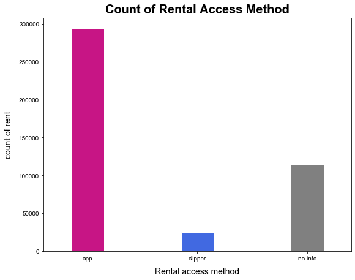

```python
set_label('Count of Rental Access Method','Rental access method','count of rent','white')
df['rental_access_method'].value_counts().sort_index().plot.bar(width=0.3,color=['mediumvioletred','royalblue','grey'])
plt.xticks(rotation=360);
```

**Observation:** Most the people who borrow these bikes are using App with around 290,000 rents then came no information method could be using app , clipper or using the old way from kiosk screen with around 120,000 rents then came the people who using clipper card with 25,000 rents. Most the people prefare the app rather than using Clipper card that come from third party company.

**Then usage of bike during day , week and month. Staring with the number of trips during the day hour**

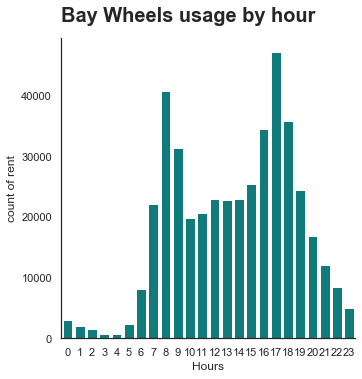

```python
hourday = sns.catplot(data=df,x='start_time_hour',kind='count',color="darkcyan");
hourday.set_axis_labels('Hours','count of rent');
hourday.fig.suptitle('Bay Wheels usage by hour',y=1.05,fontsize=20,fontweight='bold');
hourday.set_xticklabels(rotation=360);
```

**Observation:** From the figure we can see that at 8 AM and 5 PM have the most rented bike. These two time are common for starting and ending work hours. Also the previus hour and the following hour for 8 AM and 5 PM have high number of rented bikes. During the day the number of rented bike are high comparing with the night hour. Staring from 7 PM , the number of rented bike dramaticly decrease until reach 4 AM then start growing again.

**The number of rents during the week.**

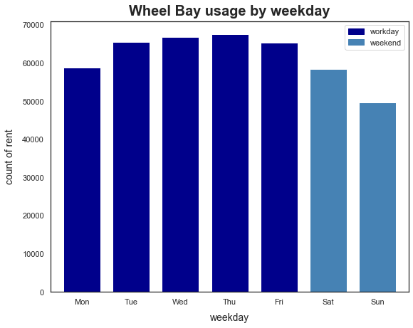

```python
weekday = ['Mon','Tue','Wed','Thu','Fri','Sat','Sun']
set_label('Wheel Bay usage by weekday','weekday','count of rent','white')
df['start_time_weekday'].value_counts().reindex(weekday).plot.bar(width=0.75,color=['darkblue','darkblue','darkblue','darkblue','darkblue','steelblue','steelblue'])
plt.xticks(rotation=360);
colors = {'workday':'darkblue', 'weekend':'steelblue'}
labels = list(colors.keys())
handles = [plt.Rectangle((0,0),1,1, color=colors[label]) for label in labels]
plt.legend(handles, labels);
```

**Observation:** the daywork are sliglty more than the weekend.

**The number of rents during the month of February.**

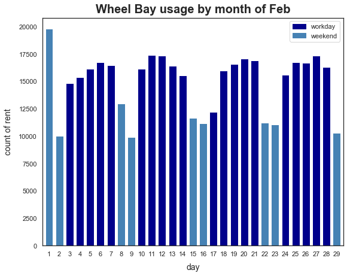

```python
set_label('Wheel Bay usage by month of Feb','day','count of rent','white')
df['start_time_day'].value_counts().sort_index().plot.bar(width=0.75,color=['steelblue','steelblue','darkblue','darkblue','darkblue','darkblue','darkblue'])
plt.xticks(rotation=360);
colors = {'workday':'darkblue', 'weekend':'steelblue'}
labels = list(colors.keys())
handles = [plt.Rectangle((0,0),1,1, color=colors[label]) for label in labels]
plt.legend(handles, labels);
```

**Observation:** Here it shown that the most days are in workday. The most day have rented bike is the first day in month and is Saturday which is a weekend day.

**Next find who are our users if they are subcribers or regular customer**

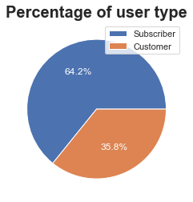

```python
sub = df.user_type.value_counts()
plt.pie(sub, labels = sub.index, startangle = 0, autopct= '%1.1f%%',  counterclock = True, textprops={'color':'white'});
plt.title('Percentage of user type', y=1, fontsize=20, fontweight='bold');
plt.legend();
```

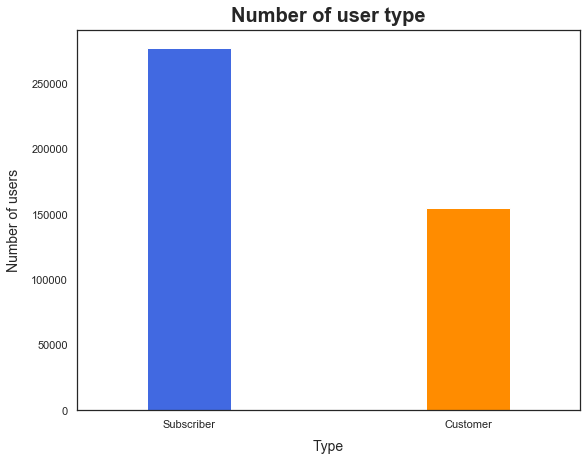

```python
set_label('Number of user type','Type','Number of users','white')
df['user_type'].value_counts().plot.bar(width=0.3,color=['royalblue','darkorange'])
plt.xticks(rotation=360);
```

**Observation:** In the Pie chart, The subscriber are 64.2% and customer are 35.8%. In the bar chart is shown that the number of subscriber are above than 250,000 and Customer are around 150,000 person.

### 2. Bivariate approtch

**start comparing between Subscriber and Customer in method of rental access and usage of bikes during day and week and month**

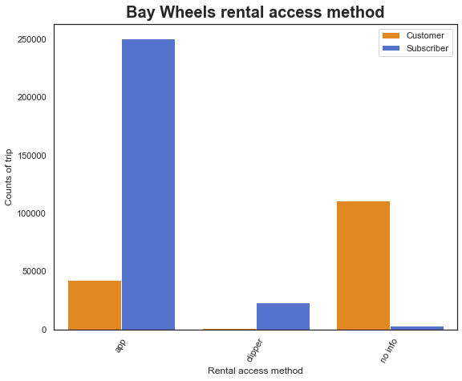

```python
my_palette = {'Subscriber': 'royalblue', 'Customer': 'darkorange'}
set_label2('Bay Wheels rental access method',"Rental access method","Counts of trip",'white','rental_access_method','user_type',my_palette);
```

**Observation:** As is shown the bar chart, Most the people who have subscribe are using the application method. On the other hand, most of the customer are using different method (most likely from kiosk screen). The people who used clipper card method are fewer than 50,000 including customer or subscriber.

**The usage bike during day for subcriber and customer**

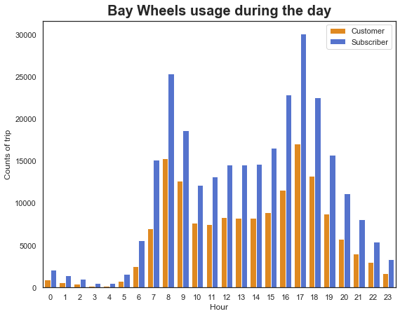

```python
my_palette = {'Subscriber': 'royalblue', 'Customer': 'darkorange'}
set_label2('Bay Wheels usage during the day',"Hour","Counts of trip",'white','start_time_hour','user_type',my_palette);
plt.xticks(rotation=360);
```

**Observation:** As is shown the bar chart, the subscriber are more than the customer during all the day hour. Also the peak for both of them are in 5 PM.

**The usage bike during week for subcriber and customer**

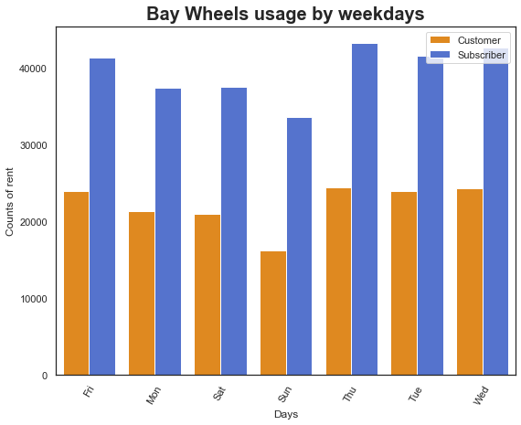

```python
my_palette = {'Subscriber': 'royalblue', 'Customer': 'darkorange'}
set_label2('Bay Wheels usage by weekdays',"Days","Counts of rent",'white','start_time_weekday','user_type',my_palette);
```

**Observation:** As is shown the bar chart, the subscriber are more than the customer during all the days of week.

**The usage bike during month of February for subcriber and customer**

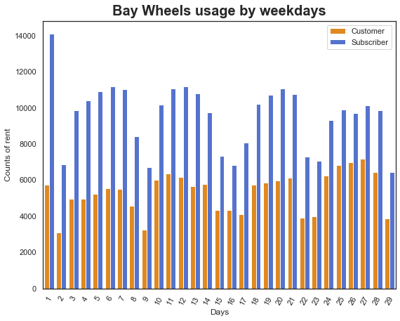

```python
my_palette = {'Subscriber': 'royalblue', 'Customer': 'darkorange'}
set_label2('Bay Wheels usage by weekdays',"Days","Counts of rent",'white','start_time_day','user_type',my_palette);
```

**Observation:** As is shown the bar chart, the subscriber are more than the customer during all the days of month.

**Aslo I want to check the usage of these bike is effected if it normal day or weekend**

```python
# Group by start_time_hour and work_end
df2 = df.loc[:,('bike_id','start_time_hour','work_end')].groupby(['start_time_hour','work_end']).agg({'bike_id':'count'}).reset_index()
```

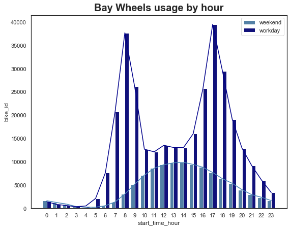

```python
#plot counts by start_time_hour on week_end
my_palette = {'workday': 'darkblue', 'weekend': 'steelblue'}

set_label2('Bay Wheels usage by hour',"Hour","Count of trips",'white','start_time_hour','work_end',my_palette)
sns.lineplot(x='start_time_hour',y='bike_id',hue='work_end',data=df2 ,palette = my_palette,legend=False)
plt.xticks(rotation=360);
```

**Observation:** From the figure we can see that the diffrance between workday and weekend days that in weekend during all the day most the people are using the bike and reach the peak at 2 PM. But because we have 5 days work days that make most the number of rents at 8 AM and 5 PM

### Multivariate Approtch

**In this section, I will start with the usage of the bike for both Subscriber and Customer during the day and comparing between workday and weekend**

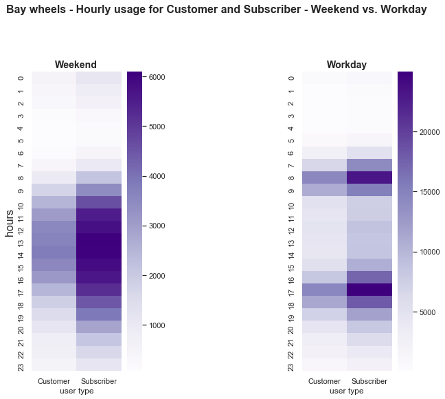

```python
plt.figure(figsize=(10,8))
plt.suptitle('Bay wheels - Hourly usage for Customer and Subscriber - Weekend vs. Workday', y=1.05, fontsize=16, fontweight='bold');


#Plotting a heatmap for Weekend
plt.subplot(1,3,1)
df_weekend = df.query('work_end == "weekend"').groupby(["user_type", "start_time_hour"])["bike_id"].size().reset_index()
df_weekend = df_weekend.pivot('start_time_hour','user_type','bike_id')
sns.heatmap(df_weekend,cmap='Purples')
plt.title("Weekend", y=1.015, fontsize=14, fontweight='bold')
plt.xlabel('user type')
plt.ylabel('hours', fontsize=16);


#Plotting a heatmap for Workday
plt.subplot(1,3,3)
df_workday = df.query('work_end == "workday"').groupby(["user_type", "start_time_hour"])["bike_id"].size().reset_index()
df_workday = df_workday.pivot('start_time_hour','user_type','bike_id')
sns.heatmap(df_workday,cmap='Purples')
plt.title("Workday", y=1.015, fontsize=14, fontweight='bold')
plt.xlabel('user type')
plt.ylabel('');
```

**Observation:** The diffrance between weekends and workdays from the heatmap:

**In weekends:** Most of the usage time from 8 AM to 8 PM for the subscriber and for customer is from 10 AM to 6 PM. Also we consider that the Subscriber are more than Customer.

**In Workday:** Most of the usage time at 8 AM and 5 PM for the subscriber and the customer. Also we consider that the Subscriber are more than Customer.

**Now the usage of the bike for method of rental access during the day and comparing between workday and weekend**

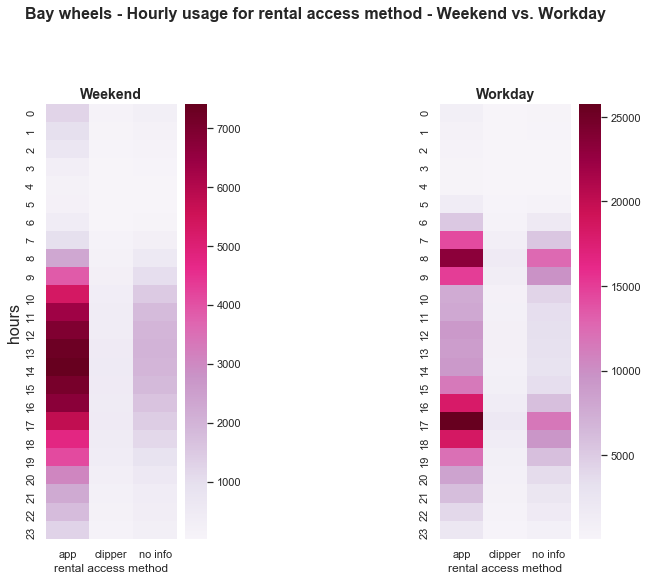

```python
plt.figure(figsize=(10,8))
plt.suptitle('Bay wheels - Hourly usage for rental access method - Weekend vs. Workday', y=1.05, fontsize=16, fontweight='bold');


#Plotting a heatmap for Weekend
plt.subplot(1,3,1)
df_weekend = df.query('work_end == "weekend"').groupby(["rental_access_method", "start_time_hour"])["bike_id"].size().reset_index()
df_weekend = df_weekend.pivot('start_time_hour','rental_access_method','bike_id')
sns.heatmap(df_weekend,cmap='PuRd')
plt.title("Weekend", y=1.015, fontsize=14, fontweight='bold')
plt.xlabel('rental access method')
plt.ylabel('hours', fontsize=16);


#Plotting a heatmap for Workday
plt.subplot(1,3,3)
df_workday = df.query('work_end == "workday"').groupby(["rental_access_method", "start_time_hour"])["bike_id"].size().reset_index()
df_workday = df_workday.pivot('start_time_hour','rental_access_method','bike_id')
sns.heatmap(df_workday,cmap='PuRd')
plt.title("Workday", y=1.015, fontsize=14, fontweight='bold')
plt.xlabel('rental access method')
plt.ylabel('');
```

**Observation:** The diffrance between weekends and workdays from the heatmap:

**In weekends:** Most of the usage time from 8 AM to 8 PM. The mobile application was the first place then came in the second place old way method (kiosk screen). Then lastly came clipper card nearly no one use this method.

**In Workday:** Most of the usage time at 8 AM and 5 PM. The mobile application was the first place during all the day. Then came in the second place old way method (kiosk screen) and it was very high on 8 AM and 5 PM (These time are rush time). Then lastly came clipper card with very few trips.

**Now the count trips of user type for method of rental access and comparing between workday and weekend**

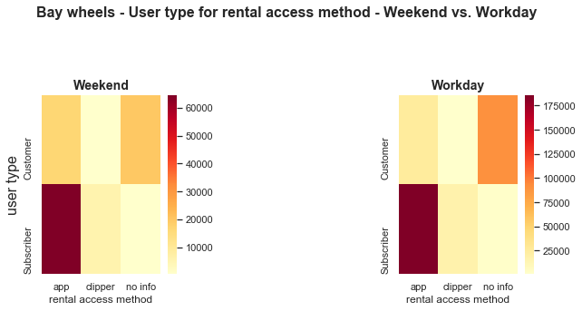

```python
plt.figure(figsize=(10,8))
plt.suptitle('Bay wheels - User type for rental access method - Weekend vs. Workday', y=1.05, fontsize=16, fontweight='bold');


#Plotting a heatmap for Weekend
plt.subplot(2,3,1)
df_weekend = df.query('work_end == "weekend"').groupby(["rental_access_method","user_type"])["bike_id"].size().reset_index()
df_weekend = df_weekend.pivot("user_type",'rental_access_method','bike_id')
sns.heatmap(df_weekend,cmap='YlOrRd')
plt.title("Weekend", y=1.015, fontsize=14, fontweight='bold')
plt.xlabel('rental access method')
plt.ylabel('user type', fontsize=16);


#Plotting a heatmap for Workday
plt.subplot(2,3,3)
df_workday = df.query('work_end == "workday"').groupby(["rental_access_method","user_type"])["bike_id"].size().reset_index()
df_workday = df_workday.pivot("user_type",'rental_access_method','bike_id')
sns.heatmap(df_workday,cmap='YlOrRd')
plt.title("Workday", y=1.015, fontsize=14, fontweight='bold')
plt.xlabel('rental access method')
plt.ylabel('');
```

**Observation:** The diffrance between weekends and workdays from the heatmap:

**In weekends:** Most method using for subscriber is mobile application then clipper card and the last place kiosk screen. On the other side, customer they using kiosk little bit more than the application then last place clipper card.

**In Workday:** Most method using for subscriber is mobile application then clipper card and the last place kiosk screen. On the other side, customer they using kiosk then the mobile application then last place clipper card.